# Assignment 6

SDS3386

Maia Pelletier (8245669)

2019-11-12

**Libraries used**: Libraries used in this code are *tidyverse*, *readxl*, *janitor*, *ggthemes*, *viridis*, *kableExtra*, *broom*, *sf*, *ggsflabel*, and *gghighlight*. Please install these libraries before knitting.

**Data used**: Data used in this code is *Ottawa municipal election data from 2018*, *Ottawa census data from 2016*, and *Ottawa wards shape data* (from City of Ottawa and attached to assignment submission). Please make sure this data is in working direction before knitting.

```r
# Load libraries
library(tidyverse)
library(janitor)
library(readxl)
library(ggthemes)
library(viridis)
library(kableExtra)
library(broom)
library(sf)
library(ggsflabel)
library(gghighlight)

# Set theme for graphics
theme_set(theme_minimal())

# Set data paths to be read
ward_data <- 'statementofvotescastoctober242018.xls'
shpfile <- 'WardsShp/Wards.shp'
census_data <- 'census_2016.csv'
```

# Description

We are interested in investigating whether close election races lead to higher voter turn-out, using data collected from the 2018 Ottawa municipal election.

# Does voter turnout increase for close election races?

The first thing we are interested in investigating is how close the races in each ward actually were. It is important to note that I made the assumption to remove the *Special Advanced polls*. This is discussed in detail in the **Comments** section of the report.

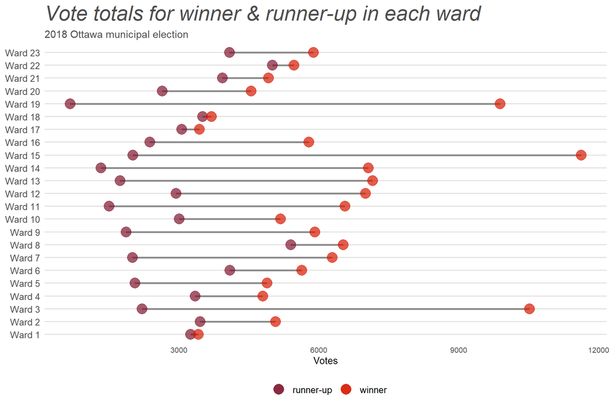

```r
get_winners <- function(ward, num_of_winners = 1){

# Function to retrieve the sepcified number of winners in a ward, given a
# dataframe containing voting totals.

  # Clean voting data
  clean_ward <-
    ward %>%
    clean_names() %>%
    select(-starts_with('x')) %>%
    na.omit() %>%
    select(-precinct_7) %>%
    rename(precinct = precinct_1) %>%
    filter(!str_detect(precinct, 'Total'))

  # Make dataframe longer (gather candidates into one column)
  ward_long <-
    clean_ward %>%
    # Filter out special advanced polling
    filter(!str_detect(precinct, 'Spc')) %>%
    pivot_longer(5:(ncol(clean_ward)-1), names_to = 'candidate', values_to = 'votes') %>%
    # Make candidate names more readable
    mutate(candidate = str_to_title(str_replace_all(candidate, '_', ' '))) %>%
    # Seperate polling station number from name
    separate(precinct, c('precinct_id', 'precinct_name'), sep = ' - ', extra = 'merge')

  # Select row containing ward winner(s)
   ward_winner <-
    ward_long %>%
    group_by(precinct_name, candidate) %>%
    summarise(votes = sum(votes)) %>%
    ungroup() %>%
    group_by(candidate) %>%
    summarise(total_candidate_votes = sum(votes)) %>%
    mutate(total_ward_votes = sum(total_candidate_votes),
           frac_candidate_votes = total_candidate_votes/total_ward_votes) %>%
    # Take defined number of top vote-getters
    top_n(num_of_winners, total_candidate_votes)

  return(ward_winner)
}

num_of_wards <- 23 # Number of wards in Ottawa

ward_winners_df <- tibble() # Empty df to append to

# Iterate over number of wards to build df of ward winners
for (i in 1:num_of_wards) {
  add_ward <- get_winners(read_excel(ward_data, sheet = i + 2, skip = 2), num_of_winners = 2)
  ward_winners_df <- bind_rows(ward_winners_df, mutate(add_ward, ward = i))
}

# Widen ward winner df
ward_winners_wide <-
  ward_winners_df %>%
  group_by(ward) %>%
  mutate(maxvotes = max(total_candidate_votes)) %>%
  mutate(rank = ifelse(total_candidate_votes == maxvotes, 'winner', 'runner-up')) %>%
  select(-maxvotes, -candidate, -frac_candidate_votes, -total_ward_votes) %>%
  pivot_wider(names_from = rank, values_from = total_candidate_votes)

# Plot ward winner and runner-up
ggplot(ward_winners_wide) +
  geom_segment(aes(x = factor(ward), xend = ward, y = `runner-up`, yend = winner), size = 1, color = 'grey55') +
  geom_point(aes(x = ward, y = `runner-up`, color = 'runner-up'), size = 5, alpha = 0.7) +
  geom_point(aes(x = ward, y = winner, color = 'winner'), size = 5, alpha = 0.7) +
  coord_flip() +
  labs(x = NULL, y = 'Votes', title = 'Vote totals for winner & runner-up in each ward',
       subtitle = '2018 Ottawa municipal election') +
  scale_x_discrete(labels = paste('Ward', 1:23)) +
  scale_color_canva(palette = 'Jewel tones', name = NULL) +
  theme_hc() +
  theme(plot.title = element_text(size = 22, face = 'italic', color = 'grey30'),
        plot.subtitle = element_text(size = 11, color = 'grey30'),
        axis.text.x = element_text(size = 8),
        axis.title.x = element_text(size = 10))
```

We can see here the margin between the winner and the runner-ups in each ward in Ottawa. Wards where there are particularly close races include 1, 17, and 18. We will be interested in looking at the voter turnout in these wards in our analysis to see if they follow our hypothesis that their turnout will be higher.

The metric of interest here is the difference between the votes for the winner and the votes for the runner up, so we calculate that. I decided to use the difference between the fraction of votes here.

```r
# Find margin between winner and runner-up
margin_df <-
  ward_winners_df %>%
  group_by(ward) %>%
  mutate(minvotes = min(frac_candidate_votes)) %>%
  mutate(margin = frac_candidate_votes-minvotes) %>%
  top_n(1, total_candidate_votes)

# Show 10 closest races
margin_df %>%
  select(candidate, ward, frac_candidate_votes, margin) %>%
  arrange(margin) %>%
  head(10) %>%
  kable() %>%
  kable_styling(bootstrap_options = c("striped", "hover", "condensed"), fixed_thead = T)
```

| candidate | ward | frac_candidate_votes | margin |
| --- | --- | --- | --- |
| Matthew Luloff | 1 | 0.2369352 | 0.0115206 |
| Jean Cloutier | 18 | 0.3269588 | 0.0165560 |
| Shawn Menard | 17 | 0.2815160 | 0.0314342 |
| Carol Anne Meehan | 22 | 0.4208580 | 0.0352769 |
| Rick Chiarelli | 8 | 0.4661665 | 0.0803144 |
| Scott Moffatt | 21 | 0.5562083 | 0.1124167 |
| Laura Dudas | 2 | 0.4163383 | 0.1325944 |
| Allan Hubley | 23 | 0.4542789 | 0.1393626 |
| Jenna Sudds | 4 | 0.4642788 | 0.1404647 |
| Glen Gower | 6 | 0.5795969 | 0.1591937 |

The other thing that needs to be calculated is the voter turn-out for each ward, so that we can compare it to the margin each ward winner won by. I want to show the voter turn-out by ward on a map of the Ottawa wards (data collected of the City of Ottawa website [3]).

```r
# Read and tidy summary data
clean_summary <-
  read_excel(ward_data, sheet = 1, skip = 2) %>%
  clean_names() %>%
  select(-starts_with('x')) %>%
  filter(!is.na(registered_voters),
         !str_detect(precinct, 'City / Ville - Total'))

# Massage summary data to get turn-out
elxn_summary <-
  clean_summary %>%
  # Separate polling station no from name
  separate(precinct, c('precinct_id', 'precinct_name'), ' - ', extra = 'merge') %>%
  # Remove special advance polling
  filter(!str_detect(precinct_id, 'Spc Adv')) %>%
  # Remove advance polling identifier
  mutate(precinct_id = str_remove(precinct_id, 'Adv 1')) %>%
  # Separate ward number from polling station number
  separate(precinct_id, c('ward', 'polling_station_no'), sep = '-') %>%
  mutate(ward = as.numeric(ward)) %>%
  group_by(ward) %>%
  summarise(total_registered_voters = sum(registered_voters),
            total_cards_cast = sum(cards_cast)) %>%
  # Calculate voter turn-out
  mutate(frac_votes = total_cards_cast/total_registered_voters)

# Read Wards shapefile [Ref 2]
wrdshp <-  st_read(shpfile) %>%
  clean_names()
```

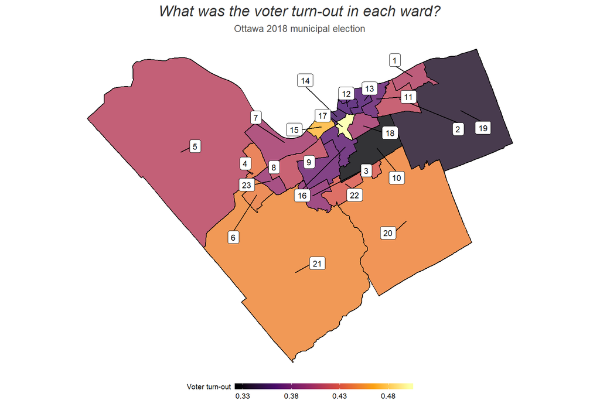

```r
# Massage data to join with shape data
ward_df <- elxn_summary %>%
  mutate(ward_num = as.character(ward)) %>%
  select(ward_num, frac_votes)

# Join with shape data
wrd_shp_df <- right_join(wrdshp, ward_df, by = 'ward_num')

# Plot sf
ggplot() +
  geom_sf(data = wrd_shp_df, aes(fill = frac_votes), alpha = 0.8, color = 'black') +
  geom_sf_label_repel(data = wrd_shp_df, aes(label = ward_num), size = 3, force = 25) +
  scale_fill_viridis_c(option = 'B', breaks = seq(0.28, 0.5, 0.05), name = 'Voter turn-out') +
  ggtitle('What was the voter turn-out in each ward?',
          subtitle = 'Ottawa 2018 municipal election') +
  theme_void() +
  theme(legend.position = 'bottom',
        plot.title = element_text(color = 'grey20', face = 'italic', size = 16, hjust = 0.5),
        plot.subtitle = element_text(color = 'grey30', size = 10, hjust = 0.5),
        legend.text = element_text(size = 8),
        legend.title = element_text(size = 8, vjust = 1),
        legend.key.height = unit(2.2, 'mm'),
        legend.key.width = unit(13.6, 'mm'))
```

We see that Ward 17 (Capital) had the highest voter turn-out in the city and Ward 10 (Gloucester-Southgate) had the lowest. These will be interesting wards to look at. Finally, we combine the voter turn-out with the margin of votes the winner won by and we are able to investigate the relationship between voter turn-out and close elections.

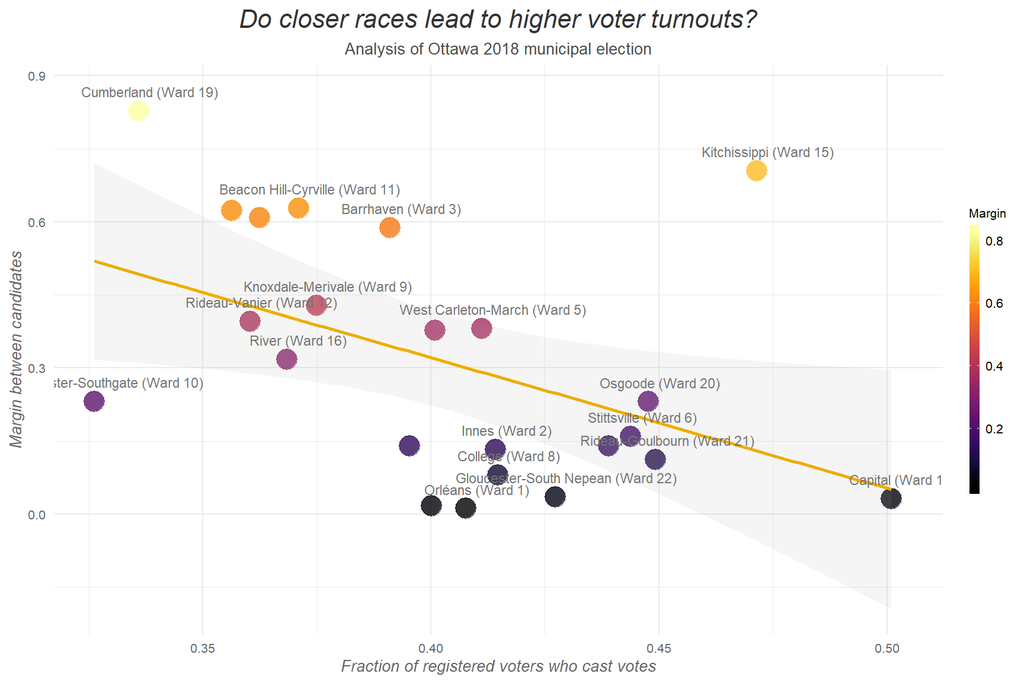

```r
# Join data together
final_df <-
  margin_df %>%
  right_join(elxn_summary, by = 'ward') %>%
  right_join(read_csv(census_data), by = c('ward' = 'number')) %>%
  rename(name = Ward)

# Final plot to investigate relationship
final_df %>%
  ggplot(aes(frac_votes, margin)) +
  geom_point(
    aes(color = margin),
    size = 6,
    alpha = 0.8
    ) +
  geom_smooth(
    formula = y ~ x,
    method = 'lm',
    alpha = 0.1,
    color = '#edae01'
    ) +
  geom_text(
    aes(label = paste0(name,' (Ward ', ward, ')')),
    nudge_y = 0.040,
    nudge_x = 0.0025,
    size = 3,
    check_overlap = TRUE,
    color = 'grey45') +
  labs(
    x = 'Fraction of registered voters who cast votes',
    y = 'Margin between candidates'
    ) +
  ggtitle('Do closer races lead to higher voter turnouts?',
          subtitle = 'Analysis of Ottawa 2018 municipal election') +
  scale_color_viridis(name = 'Margin', option = 'B') +
  theme_minimal() +
  theme(
    axis.title = element_text(color = 'grey40', face = 'italic', size = 10),
    axis.text = element_text(color = 'grey40', size = 8),
    plot.title = element_text(color = 'grey20', face = 'italic', size = 16, hjust = 0.5),
    plot.subtitle = element_text(color = 'grey30', size = 10, hjust = 0.5),
    legend.key.height = unit(12, 'mm'),
    legend.key.width = unit(2.2, 'mm'),
    legend.title = element_text(size = 8),
    legend.text = element_text(size = 8)
    )
```

Indeed, it seems that our hypothesis is supported by our plot. There is a trend that shows as the margin between the winners and their runner-up decreases, the voter turn-out in the ward increases. Note Ward 17: had the highest voter turn-out and was also one of the closest races.

To further investigate our initial claim, we preform a regression analysis to determine if the relationship between close election races and high voter turnout is significant.

```r
# Linear model
mod <- lm(margin ~ frac_votes, data = final_df)

# Coefficient summary
mod %>%
  tidy() %>%
  kable() %>%
  kable_styling(bootstrap_options = c("striped", "hover", "condensed"))
```

| term | estimate | std.error | statistic | p.value |
| --- | --- | --- | --- | --- |
| (Intercept) | 1.393054 | 0.4480226 | 3.109339 | 0.0053076 |
| frac_votes | -2.679651 | 1.1054720 | -2.423988 | 0.0244645 |

```r
# Full model summary
mod %>%
  glance() %>%
  select(1:6) %>%
  kable() %>%
  kable_styling(bootstrap_options = c("striped", "hover", "condensed"))
```

| r.squared | adj.r.squared | sigma | statistic | p.value | df |
| --- | --- | --- | --- | --- | --- |
| 0.2186255 | 0.1814172 | 0.2252747 | 5.875717 | 0.0244645 | 2 |

We can see that all of the coefficients of the model are significant at standard significance level $\alpha = 0.05$. The p-value for the model is 0.0244645, which is also significant at $\alpha$. Thus, we conclude that there is a significant relationship between the response variable, margin between the winner and runner-up, and the predictor, voter turn-out.

# Comments

### Special Advance polling

```r
clean_summary  %>%
  separate(precinct, c('precinct_id', 'precinct_name'), ' - ', extra = 'merge') %>%
  filter(str_detect(precinct_id, 'Spc Adv')) %>%
  head(6) %>%
  kable() %>%
  kable_styling(bootstrap_options = c("striped", "hover", "condensed"))
```

| precinct_id | precinct_name | registered_voters | cards_cast |
| --- | --- | --- | --- |
| Spc Adv 1 99-001 | François Dupuis Recreation Centre | 0 | 1047 |
| Spc Adv 1 99-002 | City Hall | 0 | 947 |
| Spc Adv 1 99-003 | Greenboro Community Centre | 0 | 841 |
| Spc Adv 1 99-004 | Ben Franklin Place | 0 | 1003 |
| Spc Adv 1 99-005 | Minto Recreation Complex-Barrhaven | 0 | 698 |
| Spc Adv 1 99-006 | Richcraft Recreation Complex-Kanata | 0 | 773 |

The reason I chose to remove the special advance polls is because it seems like they were day-of registration only and therefore there was no data recorded for registered voters. This was skewing the voter registration for the analysis, so I decided to exclude these polling stations.

Just out of curiousity, who were the winners of the special advance polls?

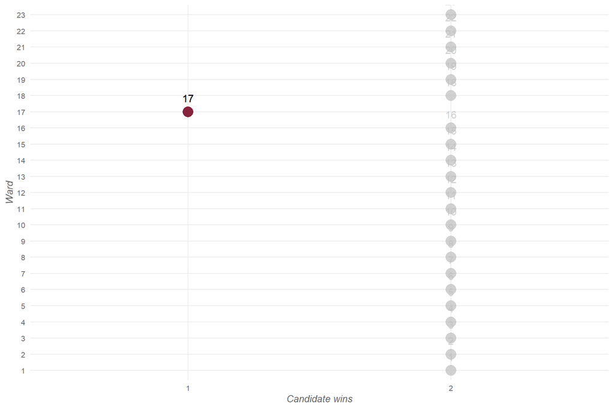

```r
get_spcadv_winners <- function(ward, num_of_winners = 1){

# Function to retrieve the sepcified number of winners in a ward, given a
# dataframe containing voting totals.

  # Clean voting data
  clean_ward <-
    ward %>%
    clean_names() %>%
    select(-starts_with('x')) %>%
    na.omit() %>%
    select(-precinct_7) %>%
    rename(precinct = precinct_1) %>%
    filter(!str_detect(precinct, 'Total'))

  # Make dataframe longer (gather candidates into one column)
  ward_long <-
    clean_ward %>%
    # Filter out special advanced polling
    filter(str_detect(precinct, 'Spc')) %>%
    pivot_longer(5:(ncol(clean_ward)-1), names_to = 'candidate', values_to = 'votes') %>%
    # Make candidate names more readable
    mutate(candidate = str_to_title(str_replace_all(candidate, '_', ' '))) %>%
    # Seperate polling station number from name
    separate(precinct, c('precinct_id', 'precinct_name'), sep = ' - ', extra = 'merge')

  # Select row containing ward winner(s)
   ward_winner <-
    ward_long %>%
    group_by(precinct_name, candidate) %>%
    summarise(votes = sum(votes)) %>%
    ungroup() %>%
    group_by(candidate) %>%
    summarise(total_candidate_votes = sum(votes)) %>%
    mutate(total_ward_votes = sum(total_candidate_votes),
           frac_candidate_votes = total_candidate_votes/total_ward_votes) %>%
    # Take defined number of top vote-getters
    top_n(num_of_winners, total_candidate_votes)

  return(ward_winner)
}

spcadv_winners_df <- tibble() # Empty df to append to

# Iterate over number of wards to build df of ward winners
for (i in 1:num_of_wards) {
  add_ward <- get_spcadv_winners(read_excel(ward_data, sheet = i + 2, skip = 2), num_of_winners = 1)
  spcadv_winners_df <- bind_rows(spcadv_winners_df, mutate(add_ward, ward = i))
}

combine_polling <-
  bind_rows(
    ward_winners_df %>%
      group_by(ward) %>%
      top_n(1, total_candidate_votes) %>%
      mutate(poll_type = 'normal'),
    spcadv_winners_df %>%
      mutate(poll_type = 'spc adv')
    )

combine_polling %>%
  count(candidate, ward) %>%
  ungroup() %>%
  ggplot(aes(factor(ward), factor(n))) +
  geom_point(aes(color = factor(n)), size = 5, alpha = 0.7, show.legend = FALSE) +
  geom_text(aes(label = ward), vjust = -1.25) +
  gghighlight(n == 1) +
  coord_flip() +
  labs(y = 'Candidate wins', x = 'Ward') +
  scale_color_canva(palette = 'Jewel tones') +
  theme(
    axis.title = element_text(color = 'grey40', face = 'italic', size = 10),
    axis.text = element_text(color = 'grey40', size = 8)
    )
```

```r
combine_polling %>%
  filter(ward == 17) %>%
  pull(candidate)
```

```
## [1] "Shawn Menard"          "Christine Mc Allister"
```

### Outliers

- **Ward 15** had a large margin of votes between the winner and the runner-up and also had a large voter turn-out. Upon further investigation, I discovered that the winner in this ward (Jeff Leiper) was up for re-election[Ref 1]. It would make sense if the voters in Ward 15 *really* liked having him as their counciller during his previous term, they would show up in large numbers to ensure his re-election.

# Suggestions for further explorations

- It would be interesting to collect demographic data for each ward (the average age, average income, etc.) to add to our model and see if this data adds information to the likeliness of a close race within a ward. I.e. Are the wards very similar or dissimilar where there are closer elections?
- It would be interesting to compare/contract the policies and promises of candidates who ran close races.

# References

[1] https://ottawacitizen.com/news/local-news/ottawa-votes-what-you-need-to-know-about-the-candidates-in-kitchissippi

[2] http://r-spatial.github.io/sf/

[3] https://open.ottawa.ca/datasets/wards